# Tutorial 1: Introduction to Data Science

## 2. Bike-Sharing

Climate change, and solutions to mitigate it, is currently on the tongues and minds of many people. One healthy and environmentally friendly transportation alternative that has been recently gaining popularity is bike-sharing. Apart from their extensive real-world applications in improving health and creating more climate-friendly transit, the data generated by these bike-sharing systems makes them great for research. In contrast to bus and subway transit systems, bike-share transit systems precisely document where a trip starts, where it ends, and how long it lasts, for each individual using the system. This level of individual traceability may allow for better detection of mobility patterns in cities and possible detection of important events.

Today, we will be analyzing [data obtained from Capital Bikeshare](http://archive.ics.uci.edu/ml/datasets/Bike+Sharing+Dataset#), a bike-sharing system from Washington, DC. The temperature data (in units of degrees Celsius) has been normalized from the original range so that all values fall between 0 and 1 (a common data processing technique helpful for some machine/statistical learning tools). Our goal is to determine if there is a relationship between temperature and the number of people renting bikes during the Spring (March 20th - June 21st).

**Question 2.1** Multiple Choice  
{points: 1}

In comparison to bike-sharing systems, why aren't other modes of transportation as useful when it comes to acquiring data?

A. Not as fast.

B. Documentation isn't as precise.

C. Not as environmentally friendly.

D. Bus drivers don't cooperate.

*Assign your answer to an object called: `answer2.1`. Make sure your answer is an uppercase letter and is surrounded by quotation marks (e.g. `"F"`).*

```r
answer2.1 <- "B"
```

```r
test_2.1()
```

```
[1] "Success!"
```

**Question 2.2** Multiple Choice  
{points: 1}

What are the units for the normalized temperature?

A. Kelvin

B. Fahrenheit

C. Celsius

*Assign your answer to an object called: `answer2.2`. Make sure your answer is an uppercase letter and is surrounded by quotation marks (e.g. `"F"`).*

```r
answer2.2 <- "C"
```

```r
test_2.2()
```

```
[1] "Success!"
```

**Question 2.3**  
{points: 1}

Since we already have `tidyverse` loaded and ready to use, the first step is to read our new data. Add in the missing function and symbol to complete the cell below. Make sure to assign your answer to `bike_data`.

```r
#... <- ...("bike_share.csv")

bike_data <- read_csv("bike_share.csv")
```

```r
test_2.3()
```

```
[1] "Success!"
```

**Question 2.4**  
{points: 1}

Mutate the data such that you have a new column called `total_users`. This column would be the sum of the `casual_users` and the `registered_users`. Assign your answer to an object called `bike_mutate`.

```r
#... <- ...(bike_data, ...)

bike_mutate <- mutate(bike_data, total_users = (casual_users + registered_users))
bike_mutate
```

A spec_tbl_df: 731 × 5

| temperature <dbl> | casual_users <dbl> | registered_users <dbl> | season <chr> | total_users <dbl> |
| --- | --- | --- | --- | --- |
| 0.344167 | 331 | 654 | Spring | 985 |
| 0.363478 | 131 | 670 | Spring | 801 |
| 0.196364 | 120 | 1229 | Spring | 1349 |
| ⋮ | ⋮ | ⋮ | ⋮ | ⋮ |
| 0.253333 | 159 | 1182 | Spring | 1341 |
| 0.255833 | 364 | 1432 | Spring | 1796 |
| 0.215833 | 439 | 2290 | Spring | 2729 |

```r
test_2.4()
```

```
[1] "Success!"
```

**Question 2.5**  
{points: 1}

Filter out the data to include information about rentals that were only made during `Spring`. Name your answer `bike_filter`.

```r
#... <- ...(bike_mutate, ... == "Spring")

bike_filter <- filter(bike_mutate, season == "Spring")
bike_filter
```

A spec_tbl_df: 181 × 5

| temperature <dbl> | casual_users <dbl> | registered_users <dbl> | season <chr> | total_users <dbl> |
| --- | --- | --- | --- | --- |
| 0.344167 | 331 | 654 | Spring | 985 |
| 0.363478 | 131 | 670 | Spring | 801 |
| 0.196364 | 120 | 1229 | Spring | 1349 |
| ⋮ | ⋮ | ⋮ | ⋮ | ⋮ |
| 0.253333 | 159 | 1182 | Spring | 1341 |
| 0.255833 | 364 | 1432 | Spring | 1796 |
| 0.215833 | 439 | 2290 | Spring | 2729 |

```r
test_2.5()
```

```
[1] "Success!"
```

**Question 2.6**  
{points: 3}

Select the columns from the data that we wish to plot. Name your answer `bike_select`.

*Hint: if you have forgetten, scroll up and re-read the introduction to this exercise.*

```r
#... <- select(...)

bike_select <- select(bike_filter, temperature, total_users)
bike_select
```

A tibble: 181 × 2

| temperature <dbl> | total_users <dbl> |
| --- | --- |
| 0.344167 | 985 |
| 0.363478 | 801 |
| 0.196364 | 1349 |
| ⋮ | ⋮ |
| 0.253333 | 1341 |
| 0.255833 | 1796 |
| 0.215833 | 2729 |

```r
# Here we check whether you have the correct object name(s). However,
# all other tests were intentionally hidden so that you can practice deciding
# when you have the correct answer.
test_that("Did not create an object named bike_select", {
    expect_true(exists("bike_select"))
})
```

**Question 2.7**  
{points: 3}

Plot the data as a scatter plot.

There is a lot missing from the cell below (no hints were given). Try completing this on your own before looking back at any previous exercises. Assign your plot to an object called `bike_plot_spring`.

*Hint: what do you think should be the x-axis / y-axis? Don't forget to label your axes! Where appropriate, axes labels should also include units (for example, the axis mapped to the `temperature` column should have the units "normalized degrees Celsius").*

```
$title
[1] "Relationship between Temperature in Spring and Total Bike Users"

attr(,"class")
[1] "labels"
```

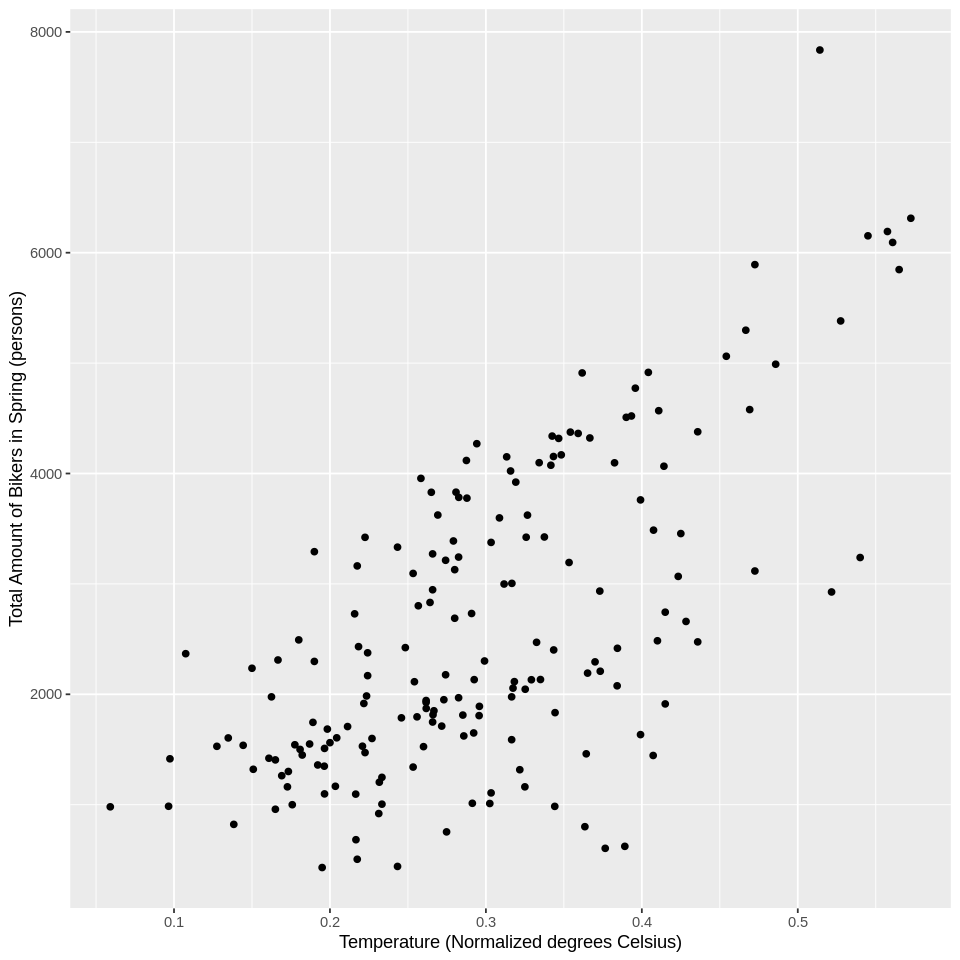

```r
# your code here
bike_plot_spring <- ggplot(bike_select, aes(x = temperature, y = total_users)) +
    geom_point() +
    ylab("Total Amount of Bikers in Spring (persons)") +
    xlab("Temperature (Normalized degrees Celsius)")
    ggtitle("Relationship between Temperature in Spring and Total Bike Users")
bike_plot_spring
```

```r
# Here we check whether you have the correct object name(s). However,
# all other tests were intentionally hidden so that you can practice deciding
# when you have the correct answer.
test_that("Did not create a plot named bike_plot_spring", {
    expect_true(exists("bike_plot_spring"))
})
```

**Question 2.8**  
{points: 3}

In 1-2 sentences, describe whether there is a relationship between the variables observed in the scatterplot of the data for the spring season. Comment on the direction and the strength of the relationship (if there is one), and how the variables change with respect to each other (if they do).

Based on the graph above, there is a moderate positive relationship between the number of people who use bikes in the Spring and the temperature in Celcius. As temperature increases, the number of bikers also increase.

## 3. Bike-Sharing Continued

For this exercise, we are going to continue working with Capital Bikeshare dataset. This part of the tutorial will focus on your understanding of how the functions work and test your ability to write code without hints. Note that we have also intentionally decreased the number of auto-graded questions for the remainder of the tutorial.

Unlike the previous exercise, we now want to determine if there is a relationship between temperature and the amount of people renting bikes during Fall (September 22nd - December 21st).

*Try completing this Exercise from start to finish without any outside help. If you are struggling with a particular question, look at Exercise 2 for assistance.*

**Question 3.1** Multiple Choice  
{points: 1}

Which column is going to be filtered during this exercise?

A. `casual_users`

B. `season`

C. `temperature`

D. `total_users`

*Assign your answer to an object called `answer3.1`. Make sure your answer is an uppercase letter and is surrounded by quotation marks (e.g. `"F"`).*

```r
answer3.1 <- "B"
```

```r
test_3.1()
```

```
[1] "Success!"
```

**Question 3.2**  
{points: 3}

Recall that the `tidyverse` package has loaded and the data has already been read. The next step is to mutate the data such that we have information on all the users. Make sure to save your answer to an object called `bike_mutated`, and make sure to create a column called `total_users`.

```r
bike_data <- read_csv("bike_share.csv")
bike_mutated <-  mutate(bike_data, total_users = (casual_users + registered_users))
bike_mutated
```

A spec_tbl_df: 731 × 5

| temperature <dbl> | casual_users <dbl> | registered_users <dbl> | season <chr> | total_users <dbl> |
| --- | --- | --- | --- | --- |
| 0.344167 | 331 | 654 | Spring | 985 |
| 0.363478 | 131 | 670 | Spring | 801 |
| 0.196364 | 120 | 1229 | Spring | 1349 |
| ⋮ | ⋮ | ⋮ | ⋮ | ⋮ |
| 0.253333 | 159 | 1182 | Spring | 1341 |
| 0.255833 | 364 | 1432 | Spring | 1796 |
| 0.215833 | 439 | 2290 | Spring | 2729 |

```r
# Here we check whether you have the correct object name(s). However,
# all other tests were intentionally hidden so that you can practice deciding
# when you have the correct answer.
test_that("Did not create an object named bike_mutated", {
    expect_true(exists("bike_mutated"))
    expect_true("total_users" %in% colnames(bike_mutated))
})
```

**Question 3.3**  
{points: 3}

Filter out the data to include information about rentals that were only made during `Fall` - assign this data frame to an object called `bike_filtered`. Next, select for the columns we wish to plot. Name your answer `bike_selected`.

```r
bike_filtered <- filter(bike_mutated, season == "Fall")
bike_filtered
bike_selected <- select(bike_filtered, temperature, total_users)
bike_selected
```

A spec_tbl_df: 188 × 5

| temperature <dbl> | casual_users <dbl> | registered_users <dbl> | season <chr> | total_users <dbl> |
| --- | --- | --- | --- | --- |
| 0.680833 | 774 | 4061 | Fall | 4835 |
| 0.733333 | 661 | 3846 | Fall | 4507 |
| 0.728333 | 746 | 4044 | Fall | 4790 |
| ⋮ | ⋮ | ⋮ | ⋮ | ⋮ |
| 0.546667 | 939 | 6781 | Fall | 7720 |
| 0.599167 | 1250 | 6917 | Fall | 8167 |
| 0.650000 | 2512 | 5883 | Fall | 8395 |

A tibble: 188 × 2

| temperature <dbl> | total_users <dbl> |
| --- | --- |
| 0.680833 | 4835 |
| 0.733333 | 4507 |
| 0.728333 | 4790 |
| ⋮ | ⋮ |
| 0.546667 | 7720 |
| 0.599167 | 8167 |
| 0.650000 | 8395 |

```r
# Here we check whether you have the correct object name(s). However,
# all other tests were intentionally hidden so that you can practice deciding
# when you have the correct answer.
test_that("Did not create an object named bike_filtered", {
    expect_true(exists("bike_filtered"))
})
test_that("Did not create an object named bike_selected", {
    expect_true(exists("bike_selected"))
})
```

**Question 3.4**  
{points: 3}

Plot the data as a scatter plot. Label your x-axis: `Temperature (normalized degrees Celsius)` and your y-axis: `Total Users (Casual and Registered)`. Assign your plot to an object called `bike_plot_fall`.

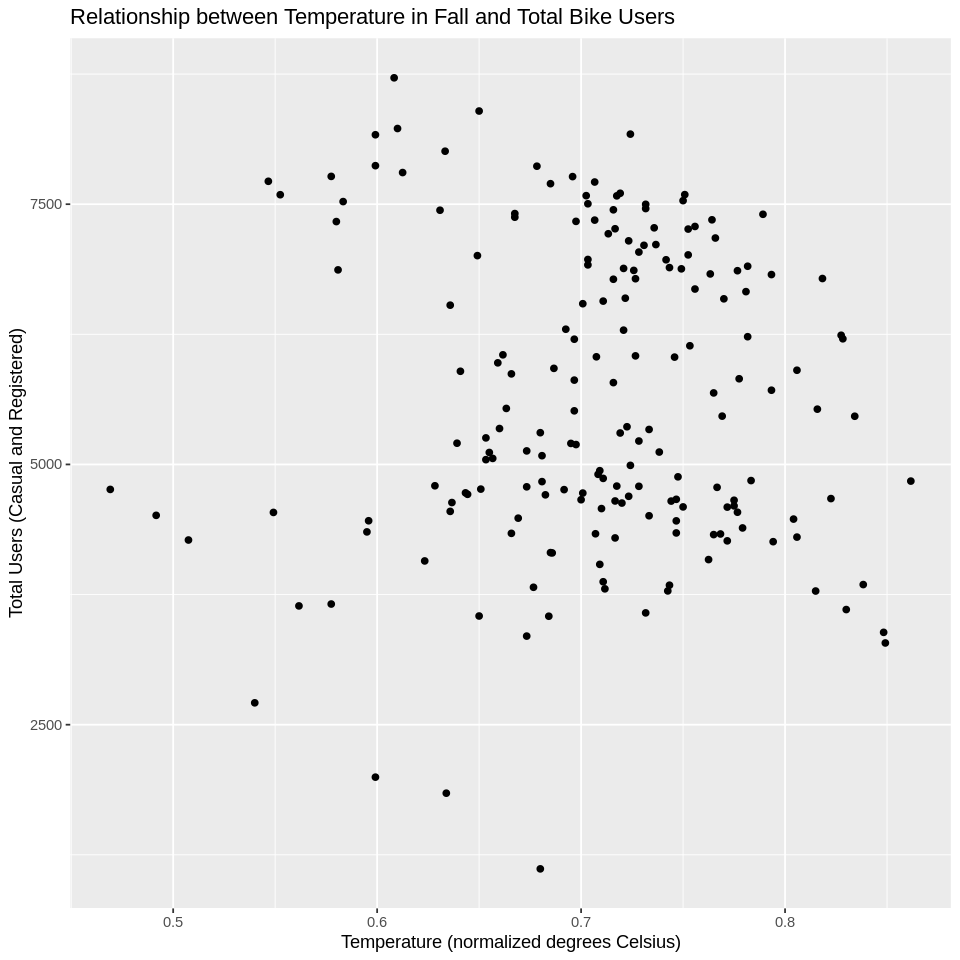

```r
bike_plot_fall <- ggplot(bike_selected, aes(x = temperature, y = total_users)) +
    geom_point() +
    ylab("Total Users (Casual and Registered)") +
    xlab("Temperature (normalized degrees Celsius)") +
    ggtitle("Relationship between Temperature in Fall and Total Bike Users")
bike_plot_fall
```

```r
# Here we check whether you have the correct object name(s). However,
# all other tests were intentionally hidden so that you can practice deciding
# when you have the correct answer.
test_that("Did not create an object named bike_plot_fall", {
    expect_true(exists("bike_plot_fall"))
})
```

**Question 3.5**  
{points: 3}

In one sentence, describe whether there is a relationship observed in the scatter plot for the fall season, and if so, the direction of that relationship.

**Question 3.6**  
{points: 3}

Looking at the scatter plots for the spring and the fall seasons, what difference(s) do you see? Based on these two plots, what might you recommend to this company to increase their users?

```r
source("cleanup_tutorial_01.R")
```